# Predicting Barbell Lift Activity From Sensor Data

sbsundog

May 24, 2016

### Executive Summary

This study implements a random forest model to predict the quality of barbell lifts performed in 20 test cases. After reducing the variable pool and training the model, the model correctly classified 20 out of 20 test validation cases.

#### Obtaining and Preparing Source Data for Barbell Model Building

The barbell lifting data contains 19622 observations and 160 variables from a study by Ugulino and Others - Wearable Computing: Accelerometers’ Data Classification of Body Postures and Movements. An additional twenty observations are to be classified based on the model constructed through this exercise. These twenty observations are the validation data set.

“Summary” data appears periodically throughout the training cases and have values for variables that the “non summary”" data does not. The two types of observations are separated. The summary data are not used in subsequent analysis.

Many variables within the non summary observations are missing data, or they are coded “NA”. Appropriate steps were taken to remove them. Observation identity information in columns 1-7 were also removed since they are not needed to build the model.

The net result is a dataset with 53 variables that will be tested for how well they fit a random forest model. The test data to be validated as a a final test of the model fitting is also reduced to 53 variables.

```r
rm(list=ls())
fileUrl <- "c:/Users/John/Documents/R/Downloads/pml-training.csv"       ##barbell lifts data file downloaded for project
bblifts.data <- read.csv(fileUrl, sep=",", header = TRUE)                ##read barbell lifts data
bblifts.data.subset <- subset(bblifts.data, bblifts.data$new_window == "yes") ##put "summary" data in its own pile
bblifts.data.subset.no <- subset(bblifts.data, bblifts.data$new_window == "no") ##put detailed data into its own pile

bblifts.data.reduced <- bblifts.data.subset.no[colSums(!is.na(bblifts.data.subset.no)) > 0] #remove NA's
bblifts.data.reduced <- bblifts.data.reduced[,colSums(bblifts.data.reduced != "") > 0] #remove coumns with spaces
bblifts.data.reduced <- bblifts.data.reduced[,c(8:60)]                      #remove identifier, non model important type data

fileUrl2 <- "c:/Users/John/Documents/R/Downloads/pml-testing.csv"          #barbell lifts TEST data file downloaded for project
bblifts.test.data <- read.csv(fileUrl2, sep=",", header = TRUE)            ##read barbell lifts TEST data
bblifts.test.data.reduced <- bblifts.test.data[colSums(!is.na(bblifts.test.data)) > 0] #remove NA's
bblifts.test.data.reduced <- bblifts.test.data.reduced[,colSums(bblifts.test.data.reduced != "") > 0] #remove columns with spaces
bblifts.test.data.reduced <- bblifts.test.data.reduced[,c(8:60)]  #remove identifier, non model type data
```

#### Partitioning Data into Training and Testing Sets

Training and testing data sets are established using the caret package.

```r
library(caret)
set.seed(1743)
inTrain <- createDataPartition(y=bblifts.data.reduced$classe, p=.75, list=FALSE)  #preliminary but standard caret setup
training <- bblifts.data.reduced[inTrain,]                                        #training data
testing <- bblifts.data.reduced[-inTrain,]                                        #testing data
```

#### Setting Up Multi Core Processing of Random Forest Model

Run times for single core processing were excessive. A multi core environment (parallel processing) was introduced to address the run time problem.

Because of execessive run times even with the multi core setup, five-fold cross validaton, rather than 10, with repetition was used in training the model. The smaller number of folds makes no practical difference in the highly accurate results.

```r
library(parallel)
library(doParallel)

tr.control.options <- trainControl(method="repeatedcv", number=5, repeats=5, allowParallel=TRUE)

x <- training[,-53]
y <- training[,53]


cluster <- makeCluster(detectCores() - 1) # convention to leave 1 core for OS
registerDoParallel(cluster)

bblifts.parallel.fit <-  train(x,y, data=training, method="rf", trControl=tr.control.options)

stopCluster(cluster)
```

### Model Results

#### Accuracy

```r
bblifts.parallel.fit
```

```
## Random Forest
##
## 14414 samples
##    52 predictor
##     5 classes: 'A', 'B', 'C', 'D', 'E'
##
## No pre-processing
## Resampling: Cross-Validated (5 fold, repeated 5 times)
## Summary of sample sizes: 11532, 11530, 11533, 11531, 11530, 11532, ...
## Resampling results across tuning parameters:
##
##   mtry  Accuracy   Kappa
##    2    0.9916471  0.9894321
##   27    0.9917025  0.9895025
##   52    0.9861665  0.9824979
##
## Accuracy was used to select the optimal model using  the largest value.
## The final value used for the model was mtry = 27.
```

#### In Sample Error Rate

```r
ins.er <- predict(bblifts.parallel.fit, training)
confusionMatrix(ins.er, training$classe)
```

```
## Confusion Matrix and Statistics
##
##           Reference
## Prediction    A    B    C    D    E
##          A 4104    0    0    0    0
##          B    0 2789    0    0    0
##          C    0    0 2514    0    0
##          D    0    0    0 2361    0
##          E    0    0    0    0 2646
##
## Overall Statistics
##
##                Accuracy : 1
##                  95% CI : (0.9997, 1)
##     No Information Rate : 0.2847
##     P-Value [Acc > NIR] : < 2.2e-16
##
##                   Kappa : 1
##  Mcnemar's Test P-Value : NA
##
## Statistics by Class:
##
##                      Class: A Class: B Class: C Class: D Class: E
## Sensitivity            1.0000   1.0000   1.0000   1.0000   1.0000
## Specificity            1.0000   1.0000   1.0000   1.0000   1.0000
## Pos Pred Value         1.0000   1.0000   1.0000   1.0000   1.0000
## Neg Pred Value         1.0000   1.0000   1.0000   1.0000   1.0000
## Prevalence             0.2847   0.1935   0.1744   0.1638   0.1836
## Detection Rate         0.2847   0.1935   0.1744   0.1638   0.1836
## Detection Prevalence   0.2847   0.1935   0.1744   0.1638   0.1836
## Balanced Accuracy      1.0000   1.0000   1.0000   1.0000   1.0000
```

#### Variable Importance

The first seven variaboles have the most impact. The gap between the seventh and the eigth is apparent.

```r
varImp(bblifts.parallel.fit)
```

```
## rf variable importance
##
##   only 20 most important variables shown (out of 52)
##
##                      Overall
## roll_belt             100.00
## pitch_forearm          59.14
## yaw_belt               54.26
## pitch_belt             44.38
## magnet_dumbbell_z      43.66
## magnet_dumbbell_y      43.53
## roll_forearm           41.64
## accel_dumbbell_y       20.68
## accel_forearm_x        17.16
## magnet_dumbbell_x      16.74
## roll_dumbbell          16.48
## magnet_belt_z          14.87
## accel_dumbbell_z       14.46
## accel_belt_z           13.61
## magnet_forearm_z       13.28
## total_accel_dumbbell   13.14
## magnet_belt_y          12.49
## gyros_belt_z           10.62
## magnet_belt_x          10.54
## yaw_arm                10.51
```

#### Out of Sample Error Rate

Accuracy is a measure of the out of sample error rate, which is how well the model handles a new data sample. A 99%+ rate is indicative that the model will predict the twenty validation cases without dififculty.

```r
oos.er <- predict(bblifts.parallel.fit, testing)
confusionMatrix(oos.er, testing$classe)
```

```
## Confusion Matrix and Statistics
##
##           Reference
## Prediction    A    B    C    D    E
##          A 1363    7    0    0    0
##          B    4  922    3    0    1
##          C    0    0  829    5    2
##          D    0    0    6  781    9
##          E    0    0    0    0  870
##
## Overall Statistics
##
##                Accuracy : 0.9923
##                  95% CI : (0.9894, 0.9946)
##     No Information Rate : 0.2847
##     P-Value [Acc > NIR] : < 2.2e-16
##
##                   Kappa : 0.9903
##  Mcnemar's Test P-Value : NA
##
## Statistics by Class:
##
##                      Class: A Class: B Class: C Class: D Class: E
## Sensitivity            0.9971   0.9925   0.9893   0.9936   0.9864
## Specificity            0.9980   0.9979   0.9982   0.9963   1.0000
## Pos Pred Value         0.9949   0.9914   0.9916   0.9812   1.0000
## Neg Pred Value         0.9988   0.9982   0.9977   0.9988   0.9969
## Prevalence             0.2847   0.1935   0.1745   0.1637   0.1837
## Detection Rate         0.2838   0.1920   0.1726   0.1626   0.1812
## Detection Prevalence   0.2853   0.1937   0.1741   0.1658   0.1812
## Balanced Accuracy      0.9975   0.9952   0.9937   0.9950   0.9932
```

#### Predictions for Observation Data

The stated goal for the project is to predict twenty observations against the fitted model. As expected, the model predicted all twenty validation cases. And so, upon submission:

Passed

20/20 points earned (100%)

Quiz passed!

```r
predict.twenty <- predict(bblifts.parallel.fit, bblifts.test.data.reduced)
predict.twenty
```

```
##  [1] B A B A A E D B A A B C B A E E A B B B
## Levels: A B C D E
```

### Appendix

Cv Error Reduction As Number of Variables Increase

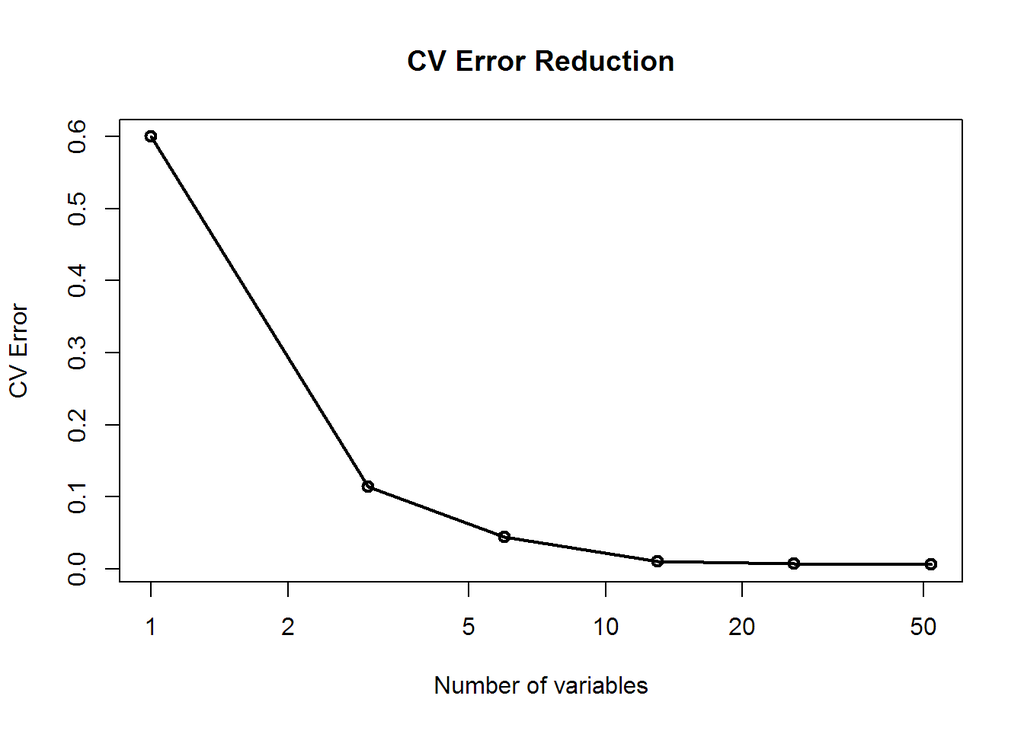

Corresponding to the above plot: the following models were run using a 53 variable model.

Results from Model Fit

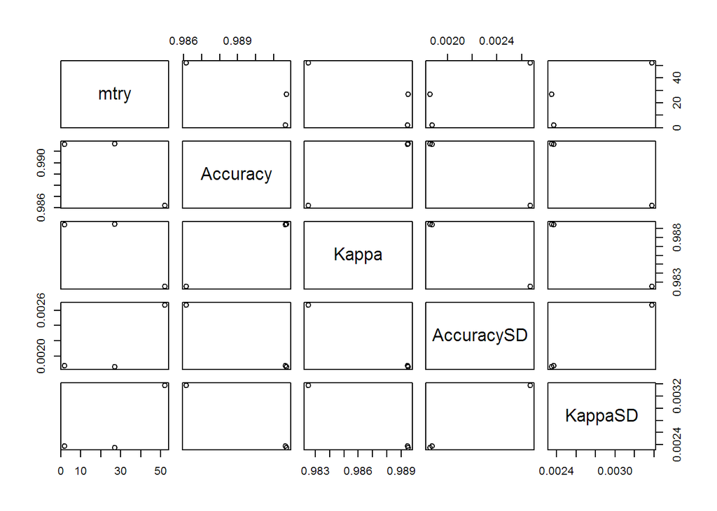